# Machine learning

The goal of this project is to predict the “class” of the exercise that the enthusisats practiced.

## How I build my model?

1. Load the datas

```r
## create machineProject and download the training and test set
if(!file.exists("machineProject")) {
        dir.create("machineProject")
}

trainingURL<-"https://d396qusza40orc.cloudfront.net/predmachlearn/pml-training.csv"
testURL<-"https://d396qusza40orc.cloudfront.net/predmachlearn/pml-testing.csv"

download.file(trainingURL, destfile="./machineProject/train.csv", method="curl")
download.file(testURL, destfile="./machineProject/test.csv", method="curl")

pml.training<-read.csv("./machineProject/train.csv", na.strings = "NA")
pml.testing<-read.csv("./machineProject/test.csv", na.strings = "NA")
```

2. Create a train set and a validation set

```r
set.seed(1234)
library(caret)
inTrain <- createDataPartition(pml.training$classe, p= 0.75, list= FALSE)

trainSet<-pml.training[inTrain,]
ValSet <- pml.training[-inTrain,]
testSet <- pml.testing
```

3. I did check that the different class are enough represented to build a prediction model

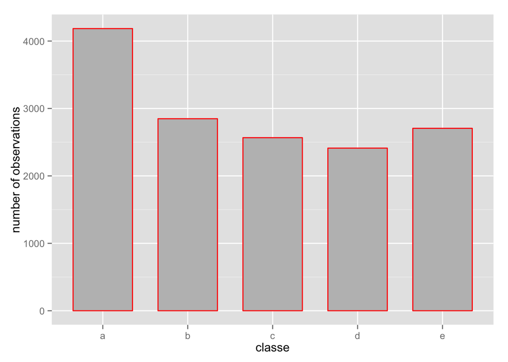

```r
a<-nrow(trainSet[trainSet$classe=="A",])
b<-nrow(trainSet[trainSet$classe=="B",])
c<-nrow(trainSet[trainSet$classe=="C",])
d<-nrow(trainSet[trainSet$classe=="D",])
e<-nrow(trainSet[trainSet$classe=="E",])

summ <- as.vector(c(a,b,c,d,e))
histo<-as.data.frame(summ)
rownames(histo)<-c("a", "b", "c", "d", "e")

library(ggplot2)
ggplot(data=histo, aes(x=rownames(histo), y = histo$summ))+
        geom_bar(stat= "identity", fill= "grey", colour= "red", width=.7)+
        ylab("number of observations")+
        xlab("classe")
```

```r
## which variable have very low variance and might be discarded?
nsv<- nearZeroVar(trainSet)
tidyTrain<-trainSet[, -c(nsv)]

## Discard columns with NA > 90% of observations

veryTidyTrain <-tidyTrain[,colSums(is.na(tidyTrain[,1:length(colnames(tidyTrain))]))< (length(row.names(tidyTrain)))/100]

## Make vector from name of variable to  use as predictors (excluding classe because it will be my outcome and the first 6 columns as they will confuse the random forest function)
trainVariable<- colnames(veryTidyTrain)
trainVariable <- trainVariable[-c(1:6,length(trainVariable))]
```

5. Then I will try and make a prediction model based on tree classification, method = randomforest. I didn’t perform any other preprocessing of the data (such as normalization or PCA) because the tree classification usually doesn’t need such preprocessing (in contrast with linear regression). I prefer randomForest() then train() because it is way faster then train forest.

```r
library(randomForest)
fitTree<-randomForest(x=veryTidyTrain[,trainVariable], y = veryTidyTrain$classe, data = veryTidyTrain, ntree= 50)
```

# How do I estimate the out of sample error rate

Now that we have a model tree, we’ll try to make prediction on the validation Set (valSet) and evaluate out of sample error rate

```r
## first make the same transformation to the validation set as we did with train set
nsv2<- nearZeroVar(ValSet)
tidyVal<-ValSet[, -c(nsv2)]

## Discard columns with NA > 90% of observations

veryTidyVal <-tidyVal[,colSums(is.na(tidyVal[,1:length(colnames(tidyVal))]))< (length(row.names(tidyVal)))/100]
veryTidyVal<-veryTidyVal[, trainVariable]
```

The out of sample rror rate is given my the confusion matrix.

```r
## Predict classe in test set using our fitTree model
classPrediction<-predict(fitTree, newdata= veryTidyVal)

## Check how our prediction match reality
confusionMatrix(data= classPrediction, reference = ValSet$classe)
```

```
## Confusion Matrix and Statistics
##
##           Reference
## Prediction    A    B    C    D    E
##          A 1394    4    0    0    0
##          B    1  943   10    0    0
##          C    0    2  843    7    0
##          D    0    0    2  797    0
##          E    0    0    0    0  901
##
## Overall Statistics
##
##                Accuracy : 0.995
##                  95% CI : (0.992, 0.997)
##     No Information Rate : 0.284
##     P-Value [Acc > NIR] : <2e-16
##
##                   Kappa : 0.993
##  Mcnemar's Test P-Value : NA
##
## Statistics by Class:
##
##                      Class: A Class: B Class: C Class: D Class: E
## Sensitivity             0.999    0.994    0.986    0.991    1.000
## Specificity             0.999    0.997    0.998    1.000    1.000
## Pos Pred Value          0.997    0.988    0.989    0.997    1.000
## Neg Pred Value          1.000    0.998    0.997    0.998    1.000
## Prevalence              0.284    0.194    0.174    0.164    0.184
## Detection Rate          0.284    0.192    0.172    0.163    0.184
## Detection Prevalence    0.285    0.195    0.174    0.163    0.184
## Balanced Accuracy       0.999    0.995    0.992    0.995    1.000
```

## Let’s predict the outcome of the test set

```r
## Make same transformation to test set as we did with training set
nsv3<- nearZeroVar(testSet)
tidyTest<-testSet[, -c(nsv3)]

## Discard columns with NA > 90% of observations

veryTidyTest <-tidyTest[,colSums(is.na(tidyTest[,1:length(colnames(tidyTest))]))< (length(row.names(tidyTest)))/100]
veryTidyTest<-veryTidyTest[, trainVariable]

## make the classe prediction on test set
predtest<- predict(fitTree, newdata = veryTidyTest)
knitr::kable(data.frame("test id" = c(1:20),"classe prediction" = predtest))
```

```
##
##
## | test.id|classe.prediction |
## |-------:|:-----------------|
## |       1|B                 |
## |       2|A                 |
## |       3|B                 |
## |       4|A                 |
## |       5|A                 |
## |       6|E                 |
## |       7|D                 |
## |       8|B                 |
## |       9|A                 |
## |      10|A                 |
## |      11|B                 |
## |      12|C                 |
## |      13|B                 |
## |      14|A                 |
## |      15|E                 |
## |      16|E                 |
## |      17|A                 |
## |      18|B                 |
## |      19|B                 |
## |      20|B                 |
```